# TFM_PART3_ESTUDI_ALZHEIMER_20210603_FINAL_20210606

```python
import pandas as pd

import numpy as np
from numpy import mean
from numpy import std
from numpy.random import seed
from numpy.random import randn

import seaborn as sns

from scipy import stats
from scipy.stats import t
from scipy.stats import ttest_ind

from matplotlib import pyplot as plt
from matplotlib import cm as cm
import statistics
import plotly.express as px

from plotly.offline import init_notebook_mode, iplot
from plotly.graph_objs import *
init_notebook_mode(connected=True)


from numpy.random import default_rng
```

```python
import warnings
warnings.filterwarnings("ignore")
```

**Lectura Catàleg GWAS**

```python
gens_f = pd.read_csv('D:/TFM/GWAS_Cataleg/gwas_catalog_v1.0.2-associations_e100_r2021-04-12.tsv',sep='\t',usecols=["DISEASE/TRAIT", "UPSTREAM_GENE_ID", "DOWNSTREAM_GENE_ID", "SNP_GENE_IDS","LINK"])
gens_f.fillna('', inplace=True)
gens_f['DISEASE/TRAIT'] = gens_f['DISEASE/TRAIT'].str.upper()

df_gens=gens_f.copy()
```

```python
gens_f.head(2)
```

|  | LINK | DISEASE/TRAIT | UPSTREAM_GENE_ID | DOWNSTREAM_GENE_ID | SNP_GENE_IDS |
| --- | --- | --- | --- | --- | --- |
| 0 | www.ncbi.nlm.nih.gov/pubmed/27863252 | GRANULOCYTE PERCENTAGE OF MYELOID WHITE CELLS | ENSG00000261156 | ENSG00000108691 |  |
| 1 | www.ncbi.nlm.nih.gov/pubmed/27863252 | GRANULOCYTE PERCENTAGE OF MYELOID WHITE CELLS | ENSG00000108344 | ENSG00000265799 |  |

**Càrrega del Dataset a partir del fitxer 'all_gensRAW.csv' amb tota la informació dels GENS lligats a teixits Cerebrals**

```python
teixits = pd.read_csv('D:/TFM/ANALISI_MODELS/Datasets/all_gensRAW.csv',sep =",")
```

**De tots els teixits del Cervell em quedo amb els GENS que compleixin alguna de les següents condicions:**

- C1: tinguin mean(TPM)>1
- C2: agrupats per Teixits tinguin un mean(TPM)>1 </b>

```python
#C1: tinguin mean(TPM)>1
mask_cond1 = teixits.iloc[:,3:].mean()>1

#C2: agrupats per Teixits tinguin un mean(TPM)>1
mask_cond2 = teixits.iloc[:,2:].groupby(['SMTSD']).agg(lambda x: (x.mean()>1).sum()).sum()>0

mask = mask_cond1 | mask_cond2
```

```python
print("Tenim un Total de :", mask_cond1[mask_cond1==True].shape[0] , " gens expressats en mitjana(TPM)>1 considerant tots els teixits")

print("Tenim un Total de :", mask_cond2[mask_cond2==True].shape[0] , " gens amb mitjana(TPM)>1 individualment en algun teixit")
```

```
Tenim un Total de : 17515  gens expressats en mitjana(TPM)>1 considerant tots els teixits
Tenim un Total de : 21231  gens amb mitjana(TPM)>1 individualment en algun teixit
```

```python
different_locations = (mask_cond1 != mask_cond2)

difference = different_locations
changed = difference[difference]

mask_cond3 = teixits.iloc[:,2:].groupby(['SMTSD']).agg(lambda x: (x.mean()>1).sum()).sum()==1

different_1teixit = (teixits.iloc[:,3:].mean()<1 & mask_cond3)

difference_1t = different_1teixit
changed_1t = difference[difference_1t]

print("Tenim un Total de :", changed_1t.shape[0] , " gens No expressats en mitjana(TPM)>1 tenint en compte tots els teixits però que si ho estan en 1 teixit")
```

```
Tenim un Total de : 1051  gens No expressats en mitjana(TPM)>1 tenint en compte tots els teixits però que si ho estan en 1 teixit
```

```python
#Gens expressats sols en 1 teixit amb mean(TPM)>1

print(mask_cond3[mask_cond3==True].shape[0])
```

```
1059
```

**Aplico les condicions de filtrat en els gens associats al cervell**

```python
#Definició 'teixits_gens': Relació de gens filtrats base associats al cervell

teixits_gens = teixits.iloc[:,3:].copy()
#Filtro pels Gens seleccionats per Mask
teixits_gens = teixits_gens.loc[:, mask]

teixits_gens['SMTSD'] = teixits['SMTSD'].values
teixits_gens = teixits_gens[ ['SMTSD'] + [ col for col in teixits_gens.columns if col != 'SMTSD' ] ]
```

```python
#Relació de gens sols expressats en 1 teixit i que estan relacionats amb l'alzheimer

teixits_gens_1only = teixits.iloc[:,3:].copy()
#Filtro pels Gens seleccionats per Mask
teixits_gens_1only = teixits_gens_1only.loc[:, mask_cond3]

teixits_gens_1only['SMTSD'] = teixits['SMTSD'].values
teixits_gens_1only = teixits_gens_1only[ ['SMTSD'] + [ col for col in teixits_gens_1only.columns if col != 'SMTSD' ] ]
```

```python
teixits_gens_1only.head(2)
```

|  | SMTSD | ENSG00000228037 | ENSG00000142606 | ENSG00000142621 | ENSG00000142623 | ENSG00000159339 | ENSG00000158816 | ENSG00000236963 | ENSG00000187942 | ENSG00000158055 | ... | ENSG00000203650 | ENSG00000187808 | ENSG00000213468 | ENSG00000232160 | ENSG00000076770 | ENSG00000225660 | ENSG00000102195 | ENSG00000269993 | ENSG00000147378 | ENSG00000267793 |
| --- | --- | --- | --- | --- | --- | --- | --- | --- | --- | --- | --- | --- | --- | --- | --- | --- | --- | --- | --- | --- | --- |
| 0 | Brain - Cortex | 0.4268 | 0.12800 | 0.40070 | 0.08174 | 1.61900 | 0.078560 | 1.4370 | 0.1769 | 0.1881 | ... | 0.5017 | 1.0110 | 0.8495 | 0.9040 | 0.7255 | 0.0 | 0.0 | 0.0 | 0.9970 | 1.247 |
| 1 | Brain - Cerebellum | 0.5863 | 0.09131 | 0.05297 | 0.18180 | 0.03529 | 0.008222 | 0.5716 | 0.1481 | 0.2657 | ... | 0.2308 | 0.5743 | 0.1225 | 0.7397 | 0.1977 | 0.0 | 0.0 | 0.0 | 0.1956 | 2.067 |

2 rows × 1060 columns

**Creació de funció auxiliar per l'obtenció a partir de GWAS dels gens lligats a una malaltia**

```python
gens_f[gens_f['DISEASE/TRAIT'].str.contains('ALZH')]
```

|  | LINK | DISEASE/TRAIT | UPSTREAM_GENE_ID | DOWNSTREAM_GENE_ID | SNP_GENE_IDS |
| --- | --- | --- | --- | --- | --- |
| 8235 | www.ncbi.nlm.nih.gov/pubmed/26830138 | ALZHEIMER DISEASE AND AGE OF ONSET |  |  | ENSG00000249910 |
| 8236 | www.ncbi.nlm.nih.gov/pubmed/26830138 | ALZHEIMER DISEASE AND AGE OF ONSET | ENSG00000255199 | ENSG00000255442 |  |
| 8237 | www.ncbi.nlm.nih.gov/pubmed/26830138 | ALZHEIMER DISEASE AND AGE OF ONSET |  |  | ENSG00000124942 |
| 8238 | www.ncbi.nlm.nih.gov/pubmed/26830138 | ALZHEIMER DISEASE AND AGE OF ONSET |  |  | ENSG00000179071 |
| 8239 | www.ncbi.nlm.nih.gov/pubmed/26830138 | ALZHEIMER DISEASE AND AGE OF ONSET | ENSG00000245552 | ENSG00000250390 |  |
| ... | ... | ... | ... | ... | ... |
| 200024 | www.ncbi.nlm.nih.gov/pubmed/33541420 | ALZHEIMER'S DISEASE OR DIASTOLIC BLOOD PRESSUR... |  |  | ENSG00000128512 |
| 200025 | www.ncbi.nlm.nih.gov/pubmed/33541420 | ALZHEIMER'S DISEASE OR HDL LEVELS (PLEIOTROPY) |  |  | ENSG00000138600 |
| 200026 | www.ncbi.nlm.nih.gov/pubmed/33541420 | ALZHEIMER'S DISEASE OR LDL LEVELS (PLEIOTROPY) |  |  | ENSG00000149927 |
| 200027 | www.ncbi.nlm.nih.gov/pubmed/33541420 | ALZHEIMER'S DISEASE OR SYSTOLIC BLOOD PRESSURE... |  |  | ENSG00000159640 |
| 200028 | www.ncbi.nlm.nih.gov/pubmed/33541420 | ALZHEIMER'S DISEASE OR WAIST-HIP RATIO (PLEIOT... |  |  | ENSG00000158859 |

1778 rows × 5 columns

**Funció 'gens_malaltia' que em recupera la relació de gens lligats a 1 malaltia ND**

```python
#ND tipus: alzheimer, parkinson, motor neurone, prion, huntington, spinocerebellar ataxia
#spinal muscular atrophy, amyotrophic lateral sclerosis, friedreich, lewy body, Creutzfeldt

#Funció que em recupera la relació de gens lligats a 1 malaltia ND

def gens_malaltia (malaltia):
    gens_malaltia = gens_f[gens_f['DISEASE/TRAIT'].str.contains(malaltia.upper())]
    estudis_malaltia = gens_malaltia.LINK.unique()

    arr_gens=[]

    for index, row in gens_malaltia.iterrows():

        if row[2].strip()!='':  #UPSTREAM_GENE_ID
            arr_gens = np.append(arr_gens, row[2].replace(', ', ' ').split(' '))
        if row[3].strip()!='':  #DOWNSTREAM_GENE_ID
            arr_gens = np.append(arr_gens, row[3].replace(', ', ' ').split(' '))
        if row[4].strip()!='':  #SNP_GENE_IDS
            arr_gens = np.append(arr_gens, row[4].replace(', ', ' ').split(' '))

        #Elimino elements Repetits
        arr_gens = np.unique(arr_gens, axis=0)

    return gens_malaltia, arr_gens, estudis_malaltia
```

**Obtenció de GWAS de gens lligats a Alzheimer**

```python
rel_gens_malaltia, llista_gens, estudis_malaltia = gens_malaltia('alzheim')
print("Número de gens lligats a l'Alzheimer a partir de GWAS: ", len(llista_gens))
```

```
Número de gens lligats a l'Alzheimer a partir de GWAS:  1432
```

**Número d'estudis lligats a la Malaltia**

```python
print('Hi ha un total de: %d estudis lligats a Alzheimer' %len(estudis_malaltia))
```

```
Hi ha un total de: 73 estudis lligats a Alzheimer
```

**Filtro els Gens del Cervell amb els relacionats amb la malaltia**

```python
data_malaltia = teixits_gens[np.intersect1d(teixits_gens.columns, llista_gens)]

data_malaltia['SMTSD'] = teixits_gens['SMTSD'].values
data_malaltia = data_malaltia[ ['SMTSD'] + [ col for col in data_malaltia.columns if col != 'SMTSD' ] ]

print("Número de gens existents lligats a l'Alzheimer en el nostre dataset prefiltrat: ", data_malaltia.shape[1]-1)
```

```
Número de gens existents lligats a l'Alzheimer en el nostre dataset prefiltrat:  644
```

```python
#Relació de gens sols expressats en 1 teixit i que estan relacionats amb l'alzheimer

data_malaltia_1only = teixits_gens_1only[np.intersect1d(teixits_gens_1only.columns, llista_gens)]

data_malaltia_1only['SMTSD'] = teixits_gens['SMTSD'].values
data_malaltia_1only = data_malaltia_1only[ ['SMTSD'] + [ col for col in data_malaltia_1only.columns if col != 'SMTSD' ] ]

print("Número de gens existents lligats a l'Alzheimer en el nostre dataset prefiltrat amb gens sols exp. en 1 texit: ", data_malaltia_1only.shape[1]-1)

data_malaltia_1only
```

```
Número de gens existents lligats a l'Alzheimer en el nostre dataset prefiltrat amb gens sols exp. en 1 texit:  23
```

|  | SMTSD | ENSG00000087589 | ENSG00000121797 | ENSG00000142178 | ENSG00000145703 | ENSG00000145779 | ENSG00000147889 | ENSG00000161929 | ENSG00000163380 | ENSG00000166035 | ... | ENSG00000231589 | ENSG00000240499 | ENSG00000255364 | ENSG00000259434 | ENSG00000261617 | ENSG00000265206 | ENSG00000266903 | ENSG00000270876 | ENSG00000271850 | ENSG00000273540 |
| --- | --- | --- | --- | --- | --- | --- | --- | --- | --- | --- | --- | --- | --- | --- | --- | --- | --- | --- | --- | --- | --- |
| 0 | Brain - Cortex | 0.6364 | 0.1855 | 0.80100 | 0.2098 | 0.1184 | 0.5611 | 0.22560 | 0.5546 | 0.47000 | ... | 0.1197 | 0.11590 | 0.00000 | 0.0 | 0.63040 | 0.3692 | 0.3842 | 1.2830 | 0.05829 | 0.39170 |
| 1 | Brain - Cerebellum | 0.3288 | 0.3083 | 0.97920 | 0.6363 | 0.3444 | 0.6573 | 0.45330 | 0.1717 | 0.02270 | ... | 0.0000 | 1.24300 | 0.75850 | 0.0 | 0.09896 | 0.6477 | 0.9800 | 0.5033 | 0.00000 | 0.05401 |
| 2 | Brain - Cortex | 0.5988 | 0.4248 | 1.02200 | 0.2152 | 0.2188 | 0.7411 | 0.18370 | 0.2488 | 0.46710 | ... | 0.0000 | 0.02564 | 0.00000 | 0.0 | 0.20640 | 0.2498 | 3.4420 | 0.7566 | 0.00000 | 0.13110 |
| 3 | Brain - Cerebellum | 0.2591 | 0.1404 | 0.59280 | 0.1074 | 0.2016 | 0.4714 | 0.10160 | 0.1633 | 0.01163 | ... | 0.0000 | 1.28900 | 0.58280 | 0.0 | 0.11150 | 0.3492 | 2.7420 | 0.6016 | 0.00000 | 0.04256 |
| 4 | Brain - Cortex | 0.6107 | 0.7053 | 0.03394 | 0.1903 | 0.1167 | 0.8154 | 0.21600 | 0.2556 | 0.62900 | ... | 0.0000 | 0.02312 | 0.00000 | 0.0 | 0.32200 | 0.1040 | 0.4982 | 0.3412 | 0.00000 | 0.20270 |
| ... | ... | ... | ... | ... | ... | ... | ... | ... | ... | ... | ... | ... | ... | ... | ... | ... | ... | ... | ... | ... | ... |
| 2636 | Brain - Cortex | 0.1638 | 0.3487 | 1.90100 | 0.2448 | 0.1619 | 0.2758 | 0.11360 | 0.3177 | 0.30110 | ... | 0.0000 | 0.11220 | 0.00000 | 0.0 | 0.31750 | 0.1682 | 0.9534 | 0.6728 | 0.00000 | 0.30500 |
| 2637 | Brain - Cerebellum | 0.4359 | 0.3542 | 0.01918 | 0.2967 | 0.2308 | 0.9176 | 0.07324 | 0.3064 | 0.00000 | ... | 0.0000 | 0.82310 | 0.57190 | 0.0 | 0.17910 | 0.3819 | 0.5522 | 0.7229 | 0.00000 | 0.04296 |
| 2638 | Brain - Cortex | 1.0560 | 1.2720 | 0.30980 | 0.9900 | 3.2340 | 0.6914 | 0.23010 | 0.4552 | 0.75500 | ... | 0.0000 | 0.03518 | 0.00000 | 0.0 | 0.16840 | 0.4746 | 0.2624 | 0.5839 | 0.00000 | 0.10280 |
| 2639 | Brain - Cerebellum | 0.4693 | 0.1766 | 0.64230 | 0.1235 | 0.2648 | 0.8673 | 0.05841 | 0.1769 | 0.05850 | ... | 0.0000 | 0.15630 | 0.09773 | 0.0 | 0.10200 | 0.0000 | 0.8936 | 0.7783 | 0.00000 | 0.06852 |
| 2640 | Brain - Cortex | 0.7346 | 0.4657 | 1.54700 | 0.2359 | 0.3952 | 0.6418 | 0.16630 | 0.3182 | 0.25250 | ... | 0.0000 | 0.03748 | 0.00000 | 0.0 | 0.63600 | 0.2107 | 2.6090 | 0.5702 | 0.05654 | 0.04878 |

2641 rows × 24 columns

```python
#Aplico log2

data = data_malaltia.copy()

data_log = np.log2(data.iloc[:,1:]+0.0001).copy()
data_log['SMTSD'] = data['SMTSD'].values

data_log = data_log[ ['SMTSD'] + [ col for col in data_log.columns if col != 'SMTSD' ] ]
```

**Realització det Test: Recerca dels gens sobreexpressats**

**Creació de la funció 'gens_sobreexpressats' que em retornarà l'expressió dels gens i el rànking de teixits en funció de la sobreexpressió dels mateixos**

```python
#Funció que em retornarà l'expressió dels gens i el rànking de teixits en funció de la sobreexpressió dels mateixos

def gens_sobreexpressats (d_data, d_data_log):

    i=0
    num_rows = d_data.shape[1]-1

    mat_t =np.zeros((num_rows, 13))
    mat_dif =np.zeros((num_rows, 13))
    mat_dif_infra =np.zeros((num_rows, 13))

    #0.05 / Número de Tests on Numero de Tests = 13 Teixits per Número de Gens

    alpha = 0.05 / (13*(d_data.shape[1]-1))

    l_teixits = ['Brain - Cortex','Brain - Cerebellum','Brain - Frontal Cortex (BA9)',
        'Brain - Caudate (basal ganglia)','Brain - Nucleus accumbens (basal ganglia)',
        'Brain - Putamen (basal ganglia)','Brain - Hypothalamus','Brain - Spinal cord (cervical c-1)',
        'Brain - Hippocampus','Brain - Anterior cingulate cortex (BA24)',
        'Brain - Cerebellar Hemisphere','Brain - Substantia nigra','Brain - Amygdala']

    for col in d_data.columns:

        if col != 'SMTSD':

            j=0

            mat_t[i,j] = i
            mat_dif[i,j] = i
            mat_dif_infra[i,j] = i

            for teixit_ind in l_teixits:

                df_Teixit = d_data[d_data['SMTSD']==teixit_ind].loc[:,col]
                df_Altres = d_data[d_data['SMTSD']!=teixit_ind].loc[:,col]

                df_Teixit_log = d_data_log[d_data_log['SMTSD']==teixit_ind].loc[:,col]
                df_Altres_log = d_data_log[d_data_log['SMTSD']!=teixit_ind].loc[:,col]

                Ttest_indResult_greater=stats.ttest_ind(df_Teixit_log,df_Altres_log, alternative='greater', axis=0, equal_var=False)

                if Ttest_indResult_greater[1]<alpha:
                    mat_t[i,j] = 1
                    mat_dif[i,j] = df_Teixit_log.mean()-df_Altres_log.mean()
                    mat_dif_infra[i,j] = 0
                else:
                    Ttest_indResult_lower=stats.ttest_ind(df_Teixit_log,df_Altres_log, alternative='less', axis=0, equal_var=False)
                    if Ttest_indResult_lower[1]<alpha:
                        mat_t[i,j] = -1
                        mat_dif[i,j] = 0
                        mat_dif_infra[i,j] = df_Altres_log.mean() - df_Teixit_log.mean()
                    else:
                        mat_t[i,j] = 0
                        mat_dif[i,j] = 0
                        mat_dif_infra[i,j] = 0
                j=j+1

            i=i+1

    df_matriu_dif = pd.DataFrame(mat_dif, columns=l_teixits, index= d_data.columns[1:])
    df_matriu_dif_infra = pd.DataFrame(mat_dif_infra, columns=l_teixits, index= d_data.columns[1:])
    df_matriu = pd.DataFrame(mat_t, columns=l_teixits, index= d_data.columns[1:])

    llista_over = np.sum(df_matriu).tolist()

    #Ranking per quantitat sobre
    r_qty = np.sum((df_matriu[df_matriu==1].iloc[:,:]))
    r_qty = pd.DataFrame(r_qty)
    r_qty.reset_index(inplace=True)
    ranking_qty = r_qty.sort_values(by=[0], ascending=False)
    ranking_qty = ranking_qty.rename(columns = {'index': 'Teixit', 0: 'Total'}, inplace = False)

     #Ranking per quantitat infra
    r_qtyi = np.sum((df_matriu[df_matriu==-1].iloc[:,:]))
    r_qtyi = pd.DataFrame(r_qtyi)
    r_qtyi.reset_index(inplace=True)
    ranking_qtyi = r_qtyi.sort_values(by=[0], ascending=True)
    ranking_qtyi = ranking_qtyi.rename(columns = {'index': 'Teixit', 0: 'Total'}, inplace = False)

    #Sobreexpressats Ranking per: suma de diferències entre mitjanes del propi teixit i la resta
    r_qty_sobre = np.sum((df_matriu_dif.iloc[:,:]))
    r_qty_sobre = pd.DataFrame(r_qty_sobre)
    r_qty_sobre.reset_index(inplace=True)
    ranking_sobre = r_qty_sobre.sort_values(by=[0], ascending=False)
    ranking_sobre = ranking_sobre.rename(columns = {'index': 'Teixit', 0: 'Total'}, inplace = False)

    #Infraexpressats Ranking per: suma de diferències entre mitjanes del propi teixit i la resta
    r_qty_infra = np.sum((df_matriu_dif_infra.iloc[:,:]))
    r_qty_infra = pd.DataFrame(r_qty_infra)
    r_qty_infra.reset_index(inplace=True)
    ranking_infra = r_qty_infra.sort_values(by=[0], ascending=False)
    ranking_infra = ranking_infra.rename(columns = {'index': 'Teixit', 0: 'Total'}, inplace = False)

    return df_matriu_dif, df_matriu_dif_infra, df_matriu, ranking_qty, ranking_qtyi, ranking_sobre, ranking_infra
```

**1. Càlcul de gens sobreexpressats i rànkings per gens GWAS lligats a l'Alzheimer**

```python
df_mdif, df_mdif_infra, df_mate, ranking_qty, ranking_qtyi, ranking_1, ranking_2 =  gens_sobreexpressats(data, data_log)
```

Número de gens lligats a l'Alzheimer sobreexpressats per Teixit

```python
#Número de gens sobreexpressats per Teixit
np.sum((df_mate.iloc[:,:] == 1))
```

```
Brain - Cortex                               289
Brain - Cerebellum                           376
Brain - Frontal Cortex (BA9)                 293
Brain - Caudate (basal ganglia)              135
Brain - Nucleus accumbens (basal ganglia)    104
Brain - Putamen (basal ganglia)               76
Brain - Hypothalamus                         166
Brain - Spinal cord (cervical c-1)           262
Brain - Hippocampus                           83
Brain - Anterior cingulate cortex (BA24)     124
Brain - Cerebellar Hemisphere                360
Brain - Substantia nigra                     152
Brain - Amygdala                              59
dtype: int64
```

Número de gens lligats a l'Alzheimer infraexpressats per Teixit

```python
#Número de gens infraexpressats per Teixit
np.sum((df_mate.iloc[:,:] == -1))
```

```
Brain - Cortex                               145
Brain - Cerebellum                           207
Brain - Frontal Cortex (BA9)                 107
Brain - Caudate (basal ganglia)              293
Brain - Nucleus accumbens (basal ganglia)    304
Brain - Putamen (basal ganglia)              395
Brain - Hypothalamus                         173
Brain - Spinal cord (cervical c-1)           199
Brain - Hippocampus                          327
Brain - Anterior cingulate cortex (BA24)     245
Brain - Cerebellar Hemisphere                230
Brain - Substantia nigra                     277
Brain - Amygdala                             319
dtype: int64
```

```python
# Diferencia per Teixits entre el número de gens sobreexpressats i infraexpressats
sobre_e = np.sum((df_mate.iloc[:,:] == 1))
infra_e = np.sum((df_mate.iloc[:,:] == -1))

dif_e = sobre_e - infra_e

dif_e
```

```
Brain - Cortex                               144
Brain - Cerebellum                           169
Brain - Frontal Cortex (BA9)                 186
Brain - Caudate (basal ganglia)             -158
Brain - Nucleus accumbens (basal ganglia)   -200
Brain - Putamen (basal ganglia)             -319
Brain - Hypothalamus                          -7
Brain - Spinal cord (cervical c-1)            63
Brain - Hippocampus                         -244
Brain - Anterior cingulate cortex (BA24)    -121
Brain - Cerebellar Hemisphere                130
Brain - Substantia nigra                    -125
Brain - Amygdala                            -260
dtype: int64
```

Ranking per Quantitat de Gens lligats a l'Alzheimer sobreexpressats per Teixit

```python
#Ranking per Quantitat de Gens sobreexpressats per Teixit

ranking_qty
```

|  | Teixit | Total |
| --- | --- | --- |
| 1 | Brain - Cerebellum | 376.0 |
| 10 | Brain - Cerebellar Hemisphere | 360.0 |
| 2 | Brain - Frontal Cortex (BA9) | 293.0 |
| 0 | Brain - Cortex | 289.0 |
| 7 | Brain - Spinal cord (cervical c-1) | 262.0 |
| 6 | Brain - Hypothalamus | 166.0 |
| 11 | Brain - Substantia nigra | 152.0 |
| 3 | Brain - Caudate (basal ganglia) | 135.0 |
| 9 | Brain - Anterior cingulate cortex (BA24) | 124.0 |
| 4 | Brain - Nucleus accumbens (basal ganglia) | 104.0 |
| 8 | Brain - Hippocampus | 83.0 |
| 5 | Brain - Putamen (basal ganglia) | 76.0 |
| 12 | Brain - Amygdala | 59.0 |

Ranking per Quantitat de Gens lligats a l'Alzheimer sobreexpressats per Teixit a partir de la Suma de la diferencia entre el mateix i la resta

```python
#Ranking per Quantitat de Gens sobreexpressats per Teixit a partir
#de la Suma de la diferencia entre el mateix i la resta

ranking_1
```

|  | Teixit | Total |
| --- | --- | --- |
| 1 | Brain - Cerebellum | 577.406161 |
| 10 | Brain - Cerebellar Hemisphere | 574.164672 |
| 7 | Brain - Spinal cord (cervical c-1) | 372.501016 |
| 2 | Brain - Frontal Cortex (BA9) | 262.898648 |
| 0 | Brain - Cortex | 230.487880 |
| 11 | Brain - Substantia nigra | 183.415407 |
| 6 | Brain - Hypothalamus | 172.427146 |
| 3 | Brain - Caudate (basal ganglia) | 130.350246 |
| 9 | Brain - Anterior cingulate cortex (BA24) | 127.904418 |
| 4 | Brain - Nucleus accumbens (basal ganglia) | 124.248165 |
| 8 | Brain - Hippocampus | 79.230336 |
| 5 | Brain - Putamen (basal ganglia) | 70.767958 |
| 12 | Brain - Amygdala | 50.628131 |

Ranking per Quantitat de Gens lligats a l'Alzheimer infraexpressats per Teixit

```python
#Ranking per Quantitat de Gens infraexpressats per Teixit

ranking_qtyi
```

|  | Teixit | Total |
| --- | --- | --- |
| 5 | Brain - Putamen (basal ganglia) | -395.0 |
| 8 | Brain - Hippocampus | -327.0 |
| 12 | Brain - Amygdala | -319.0 |
| 4 | Brain - Nucleus accumbens (basal ganglia) | -304.0 |
| 3 | Brain - Caudate (basal ganglia) | -293.0 |
| 11 | Brain - Substantia nigra | -277.0 |
| 9 | Brain - Anterior cingulate cortex (BA24) | -245.0 |
| 10 | Brain - Cerebellar Hemisphere | -230.0 |
| 1 | Brain - Cerebellum | -207.0 |
| 7 | Brain - Spinal cord (cervical c-1) | -199.0 |
| 6 | Brain - Hypothalamus | -173.0 |
| 0 | Brain - Cortex | -145.0 |
| 2 | Brain - Frontal Cortex (BA9) | -107.0 |

Ranking per Quantitat de Gens lligats a l'Alzheimer infraexpressats per Teixit a partir de la Suma de la diferencia entre el mateix i la resta

```python
#Ranking per Quantitat de Gens infraexpressats per Teixit a partir
#de la Suma de la diferencia entre el mateix i la resta

ranking_2
```

|  | Teixit | Total |
| --- | --- | --- |
| 10 | Brain - Cerebellar Hemisphere | 384.270077 |
| 5 | Brain - Putamen (basal ganglia) | 358.494649 |
| 1 | Brain - Cerebellum | 322.619204 |
| 11 | Brain - Substantia nigra | 292.725827 |
| 7 | Brain - Spinal cord (cervical c-1) | 279.837682 |
| 12 | Brain - Amygdala | 234.314261 |
| 8 | Brain - Hippocampus | 221.214503 |
| 3 | Brain - Caudate (basal ganglia) | 216.911223 |
| 4 | Brain - Nucleus accumbens (basal ganglia) | 215.503857 |
| 9 | Brain - Anterior cingulate cortex (BA24) | 159.440671 |
| 6 | Brain - Hypothalamus | 106.176105 |
| 0 | Brain - Cortex | 98.543214 |
| 2 | Brain - Frontal Cortex (BA9) | 83.799925 |

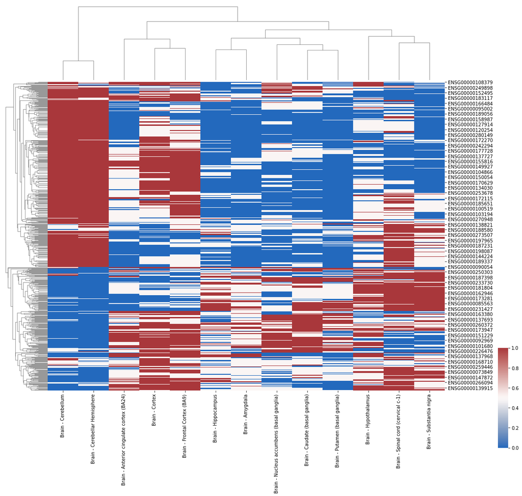

```python
#HeatMap per Expressió (gens lligats a l'Alzheimer)

g_expr_alzhe = sns.clustermap(df_mate,
                     standard_scale=1, ##estandaritza per columnes
                    figsize=(15, 15),
                   row_cluster=True,
                   cmap="vlag",
                   cbar_pos=(1, .1, .02, .2),
                   dendrogram_ratio=(.1, .2))
g_expr_alzhe.savefig('Heatmap_Express_Alzheimer.png')
```

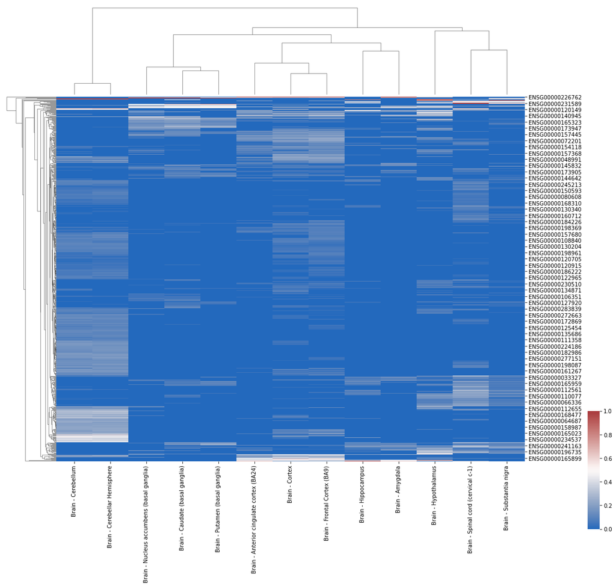

```python
#HeatMap (suma de diferències entre mitjanes del propi teixit i la resta en gens Sobreexpressats)  (gens lligats a l'Alzheimer)

g_sobre_alzh = sns.clustermap(df_mdif,
                     standard_scale=1, ##estandaritza per columnes
                    figsize=(15, 15),
                   row_cluster=True,
                   cmap="vlag",
                   cbar_pos=(1, .1, .02, .2),
                   dendrogram_ratio=(.1, .2))
g_sobre_alzh.savefig('Heatmap_SobreExpress_Alzheimer.png')
```

**2. Anàlisi de la sobreexpressió en els TOP 1000 Gens del cervell amb major mean(TPM)>1**

```python
teixits_RAW = pd.read_csv('D:/TFM/ANALISI_MODELS/Datasets/all_gensTPM_noversio_ZA.csv',sep =",")
```

```python
#Obtinc els TOP 1000
teixits_RAW_data = teixits_RAW.iloc[:,3:1003]
teixits_RAW_data['SMTSD'] = teixits_RAW['SMTSD']

teixits_RAW_data = teixits_RAW_data[ ['SMTSD'] + [ col for col in teixits_RAW_data.columns if col != 'SMTSD' ] ]


teixits_RAW_data_log = np.log2(teixits_RAW.iloc[:,3:1003]+0.0001)
teixits_RAW_data_log['SMTSD'] = teixits_RAW['SMTSD']


teixits_RAW_data_log = teixits_RAW_data_log[ ['SMTSD'] + [ col for col in teixits_RAW_data_log.columns if col != 'SMTSD' ] ]
```

**Càlcul de gens sobreexpressats i rànkings per gens TOP1000**

```python
df_mdif_raw, df_mdif_infra_raw, df_mate_raw, ranking_qty_raw, ranking_qtyi_raw, ranking_1_raw, ranking_2_raw =  gens_sobreexpressats(teixits_RAW_data, teixits_RAW_data_log)
```

Ranking TOP 1000 per Quantitat de Gens sobreexpressats per Teixit

```python
#Ranking per Quantitat de Gens sobreexpressats per Teixit

ranking_qty_raw
```

|  | Teixit | Total |
| --- | --- | --- |
| 10 | Brain - Cerebellar Hemisphere | 669.0 |
| 1 | Brain - Cerebellum | 626.0 |
| 2 | Brain - Frontal Cortex (BA9) | 603.0 |
| 0 | Brain - Cortex | 463.0 |
| 7 | Brain - Spinal cord (cervical c-1) | 375.0 |
| 9 | Brain - Anterior cingulate cortex (BA24) | 195.0 |
| 11 | Brain - Substantia nigra | 176.0 |
| 6 | Brain - Hypothalamus | 133.0 |
| 4 | Brain - Nucleus accumbens (basal ganglia) | 125.0 |
| 3 | Brain - Caudate (basal ganglia) | 122.0 |
| 12 | Brain - Amygdala | 107.0 |
| 5 | Brain - Putamen (basal ganglia) | 103.0 |
| 8 | Brain - Hippocampus | 94.0 |

```python
#Ranking per Quantitat de Gens infraexpressats per Teixit

ranking_qtyi_raw
```

|  | Teixit | Total |
| --- | --- | --- |
| 5 | Brain - Putamen (basal ganglia) | -686.0 |
| 8 | Brain - Hippocampus | -576.0 |
| 3 | Brain - Caudate (basal ganglia) | -549.0 |
| 11 | Brain - Substantia nigra | -420.0 |
| 12 | Brain - Amygdala | -395.0 |
| 7 | Brain - Spinal cord (cervical c-1) | -384.0 |
| 4 | Brain - Nucleus accumbens (basal ganglia) | -347.0 |
| 6 | Brain - Hypothalamus | -253.0 |
| 9 | Brain - Anterior cingulate cortex (BA24) | -237.0 |
| 0 | Brain - Cortex | -235.0 |
| 1 | Brain - Cerebellum | -233.0 |
| 10 | Brain - Cerebellar Hemisphere | -206.0 |
| 2 | Brain - Frontal Cortex (BA9) | -127.0 |

Ranking TOP1000per Quantitat de Gens sobreexpressats per Teixit a partir de la Suma de la diferencia entre el mateix i la resta

```python
#Ranking per Quantitat de Gens sobreexpressats per Teixit a partir
#de la Suma de la diferencia entre el mateix i la resta

ranking_1_raw
```

|  | Teixit | Total |
| --- | --- | --- |
| 10 | Brain - Cerebellar Hemisphere | 690.337007 |
| 1 | Brain - Cerebellum | 620.399209 |
| 2 | Brain - Frontal Cortex (BA9) | 416.243861 |
| 7 | Brain - Spinal cord (cervical c-1) | 376.791798 |
| 0 | Brain - Cortex | 301.403125 |
| 11 | Brain - Substantia nigra | 142.654182 |
| 9 | Brain - Anterior cingulate cortex (BA24) | 139.698719 |
| 6 | Brain - Hypothalamus | 118.535711 |
| 4 | Brain - Nucleus accumbens (basal ganglia) | 102.616742 |
| 3 | Brain - Caudate (basal ganglia) | 95.656692 |
| 8 | Brain - Hippocampus | 78.676550 |
| 5 | Brain - Putamen (basal ganglia) | 77.877720 |
| 12 | Brain - Amygdala | 74.344285 |

Ranking TOP1000 per Quantitat de Gens infraexpressats per Teixit a partir de la Suma de la diferencia entre el mateix i la resta

```python
#Ranking per Quantitat de Gens infraexpressats per Teixit a partir
#de la Suma de la diferencia entre el mateix i la resta

ranking_2_raw
```

|  | Teixit | Total |
| --- | --- | --- |
| 7 | Brain - Spinal cord (cervical c-1) | 509.771483 |
| 5 | Brain - Putamen (basal ganglia) | 454.208203 |
| 11 | Brain - Substantia nigra | 404.965866 |
| 8 | Brain - Hippocampus | 302.945958 |
| 3 | Brain - Caudate (basal ganglia) | 296.945084 |
| 10 | Brain - Cerebellar Hemisphere | 251.941079 |
| 12 | Brain - Amygdala | 239.928700 |
| 1 | Brain - Cerebellum | 235.829033 |
| 4 | Brain - Nucleus accumbens (basal ganglia) | 200.030554 |
| 6 | Brain - Hypothalamus | 173.511278 |
| 9 | Brain - Anterior cingulate cortex (BA24) | 116.972007 |
| 0 | Brain - Cortex | 98.994960 |
| 2 | Brain - Frontal Cortex (BA9) | 55.421050 |

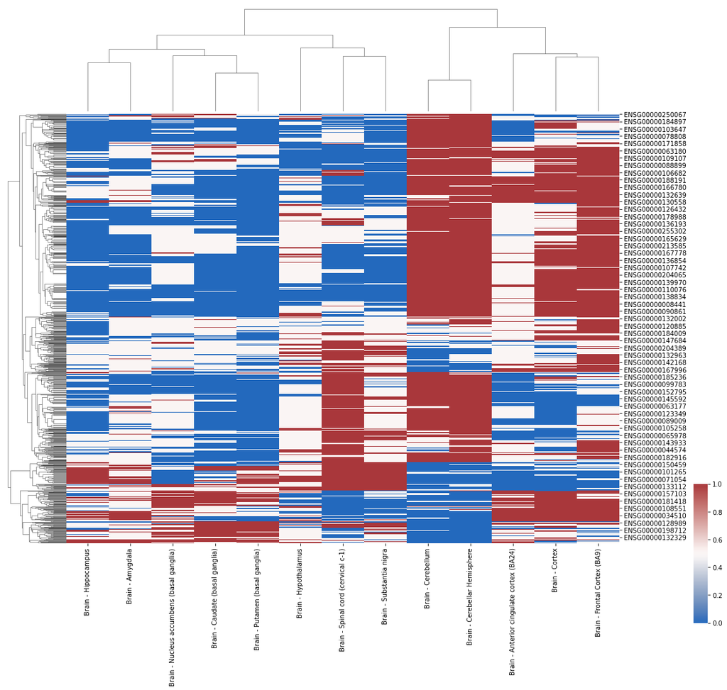

```python
#HeatMap Top 1000 per Expressió

g_expr_Top1000 = sns.clustermap(df_mate_raw,
                     standard_scale=1, ##estandaritza per columnes
                    figsize=(15, 15),
                   row_cluster=True,
                   cmap="vlag",
                   cbar_pos=(1, .1, .02, .2),
                   dendrogram_ratio=(.1, .2))
g_expr_alzhe.savefig('Heatmap_Express_TOP1000.png')
```

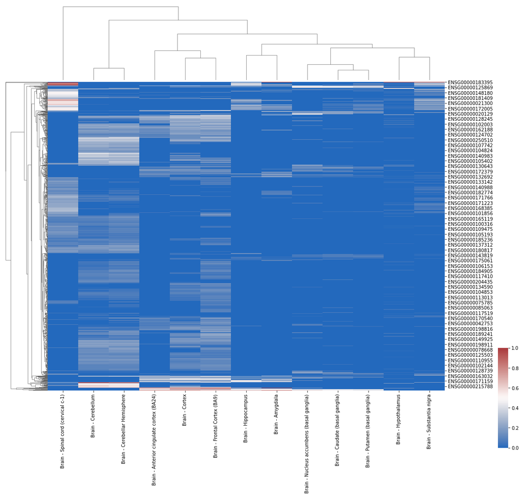

```python
#HeatMap TOP1000 (suma de diferències entre mitjanes del propi teixit i la resta en gens Sobreexpressats)

g_sobre_top1000 = sns.clustermap(df_mdif_raw,
                     standard_scale=1, ##estandaritza per columnes
                    figsize=(15, 15),
                   row_cluster=True,
                   cmap="vlag",
                   cbar_pos=(1, .1, .02, .2),
                   dendrogram_ratio=(.1, .2))
g_sobre_top1000.savefig('Heatmap_SobreExpress_top1000.png')
```

**En quina posició del ranking trobem el resultat dels Gens GWAS associats a l'Alzheimer entre 10000 iteracions del transcriptoma complert?**

```python
#Partim del Genoma Complert

teixits_gens_log = teixits_gens.copy()

teixits_gens_log = np.log2(teixits_gens_log.iloc[:,1:]+0.0001)
teixits_gens_log['SMTSD'] = teixits_gens['SMTSD'].values

teixits_gens_log = teixits_gens_log[ ['SMTSD'] + [ col for col in teixits_gens_log.columns if col != 'SMTSD' ] ]
```

## **Estudi de gens sobre expressats**

```python
#Funció reduïda que em retornarà els gens sobre expressats

def gens_sobreexpressats_lite (d_data):

    i=0
    num_rows = d_data.shape[1]-1

    mat_t =np.zeros((num_rows, 13))

    #0.05 / Número de Tests on Numero de Tests = 13 Teixits per Número de Gens

    alpha = 0.05 / (13*(d_data.shape[1]-1))

    l_teixits = ['Brain - Cortex','Brain - Cerebellum','Brain - Frontal Cortex (BA9)',
        'Brain - Caudate (basal ganglia)','Brain - Nucleus accumbens (basal ganglia)',
        'Brain - Putamen (basal ganglia)','Brain - Hypothalamus','Brain - Spinal cord (cervical c-1)',
        'Brain - Hippocampus','Brain - Anterior cingulate cortex (BA24)',
        'Brain - Cerebellar Hemisphere','Brain - Substantia nigra','Brain - Amygdala']

    for col in d_data.columns:

        if col != 'SMTSD':

            j=0

            for teixit_ind in l_teixits:

                df_Teixit = d_data[d_data['SMTSD']==teixit_ind].loc[:,col]
                df_Altres = d_data[d_data['SMTSD']!=teixit_ind].loc[:,col]

                Ttest_indResult_greater=stats.ttest_ind(df_Teixit,df_Altres, alternative='greater', axis=0, equal_var=False)

                if Ttest_indResult_greater[1]<alpha:
                    mat_t[i,j] = 1
                j=j+1

            i=i+1

    df_matriu = pd.DataFrame(mat_t, columns=l_teixits, index= d_data.columns[1:])
    llista_over = np.sum(df_matriu).tolist()

    return df_matriu, llista_over
```

```python
def ranking_n_iter (d_data, n_iter):

    l_teixits = ['Brain - Cortex','Brain - Cerebellum','Brain - Frontal Cortex (BA9)',
        'Brain - Caudate (basal ganglia)','Brain - Nucleus accumbens (basal ganglia)',
        'Brain - Putamen (basal ganglia)','Brain - Hypothalamus','Brain - Spinal cord (cervical c-1)',
        'Brain - Hippocampus','Brain - Anterior cingulate cortex (BA24)',
        'Brain - Cerebellar Hemisphere','Brain - Substantia nigra','Brain - Amygdala']

    df = pd.DataFrame(columns = ['Brain - Cortex','Brain - Cerebellum','Brain - Frontal Cortex (BA9)',
        'Brain - Caudate (basal ganglia)','Brain - Nucleus accumbens (basal ganglia)',
        'Brain - Putamen (basal ganglia)','Brain - Hypothalamus','Brain - Spinal cord (cervical c-1)',
        'Brain - Hippocampus','Brain - Anterior cingulate cortex (BA24)',
        'Brain - Cerebellar Hemisphere','Brain - Substantia nigra','Brain - Amygdala'])

    for it in range(n_iter):

        rng = default_rng()
        numbers = rng.choice(2131, size=644, replace=False)+1
        cols=numbers
        data_c = d_data.iloc[:,cols]
        data_c['SMTSD'] = d_data['SMTSD']
        data_c = data_c[ ['SMTSD'] + [ col for col in data_c.columns if col != 'SMTSD' ] ]

        matriu, llista_over =  gens_sobreexpressats_lite(data_c)

        to_append = llista_over
        a_series = pd.Series(to_append, index = df.columns)
        df = df.append(a_series, ignore_index=True)

    return df
```

```python
#Calculo 10000 iteracions entre gens seleccionats a l'atzar entre tot el transcriptoma
n_iter=1000

res = ranking_n_iter(teixits_gens_log, n_iter)
```

```python
#El càlcul dura molts dies... carrego el resultat obtingut
res = pd.read_csv('./Fitxers/10000_iteracions.csv',sep =";")
```

```python
res.head(2)
```

|  | Brain - Cortex | Brain - Cerebellum | Brain - Frontal Cortex (BA9) | Brain - Caudate (basal ganglia) | Brain - Nucleus accumbens (basal ganglia) | Brain - Putamen (basal ganglia) | Brain - Hypothalamus | Brain - Spinal cord (cervical c-1) | Brain - Hippocampus | Brain - Anterior cingulate cortex (BA24) | Brain - Cerebellar Hemisphere | Brain - Substantia nigra | Brain - Amygdala |
| --- | --- | --- | --- | --- | --- | --- | --- | --- | --- | --- | --- | --- | --- |
| 0 | 241 | 464 | 237 | 91 | 90 | 44 | 111 | 243 | 47 | 91 | 451 | 81 | 37 |
| 1 | 235 | 450 | 229 | 94 | 86 | 41 | 126 | 248 | 51 | 77 | 436 | 103 | 42 |

**Quants gens tenim més sobreexpressats (per teixit) respecte dels GWAS?**

```python
#Número de gens sobreexpressats per Teixit lligats a Alzheimer
df_alzh = pd.DataFrame(columns = ['Brain - Cortex','Brain - Cerebellum','Brain - Frontal Cortex (BA9)',
        'Brain - Caudate (basal ganglia)','Brain - Nucleus accumbens (basal ganglia)',
        'Brain - Putamen (basal ganglia)','Brain - Hypothalamus','Brain - Spinal cord (cervical c-1)',
        'Brain - Hippocampus','Brain - Anterior cingulate cortex (BA24)',
        'Brain - Cerebellar Hemisphere','Brain - Substantia nigra','Brain - Amygdala'])

to_append = np.sum((df_mate.iloc[:,:] == 1))
alzheimer_serie = pd.Series(to_append, index = df_mate.columns)
```

```python
#Quants gens tenim més sobreexpressats (per teixit) respecte dels GWAS entre 10000 iteracions del mateix número de gens
#agafats aleatòriament en el transcriptoma

n_iter = 10000

#Número de vegades en que els gens formats ens els grups aleatoris han superat en el teixit 'Cortex' els obtinguts a partir de GWAS
print('Cortex: ', res['Brain - Cortex'][res['Brain - Cortex']>alzheimer_serie[0]].count())
print('Cerebellum: ', res['Brain - Cerebellum'][res['Brain - Cerebellum']>alzheimer_serie[1]].count())

print('Frontal: ', res['Brain - Frontal Cortex (BA9)'][res['Brain - Frontal Cortex (BA9)']>alzheimer_serie[2]].count())
print('Caudate: ', res['Brain - Caudate (basal ganglia)'][res['Brain - Caudate (basal ganglia)']>alzheimer_serie[3]].count())

print('Nucleus: ', res['Brain - Nucleus accumbens (basal ganglia)'][res['Brain - Nucleus accumbens (basal ganglia)']>alzheimer_serie[4]].count())
print('Putamen: ', res['Brain - Putamen (basal ganglia)'][res['Brain - Putamen (basal ganglia)']>alzheimer_serie[5]].count())

print('Hypothalamus: ', res['Brain - Hypothalamus'][res['Brain - Hypothalamus']>alzheimer_serie[6]].count())
print('Spinal: ', res['Brain - Spinal cord (cervical c-1)'][res['Brain - Spinal cord (cervical c-1)']>alzheimer_serie[7]].count())

print('Hippocampus: ', res['Brain - Hippocampus'][res['Brain - Hippocampus']>alzheimer_serie[8]].count())
print('Anterior: ', res['Brain - Anterior cingulate cortex (BA24)'][res['Brain - Anterior cingulate cortex (BA24)']>alzheimer_serie[9]].count())

print('Cerebellar: ', res['Brain - Cerebellar Hemisphere'][res['Brain - Cerebellar Hemisphere']>alzheimer_serie[10]].count())
print('Substantia: ', res['Brain - Substantia nigra'][res['Brain - Substantia nigra']>alzheimer_serie[11]].count())

print('Amygdala: ', res['Brain - Amygdala'][res['Brain - Amygdala']>alzheimer_serie[12]].count())
```

```
Cortex:  0
Cerebellum:  10000
Frontal:  0
Caudate:  0
Nucleus:  35
Putamen:  0
Hypothalamus:  0
Spinal:  276
Hippocampus:  0
Anterior:  0
Cerebellar:  10000
Substantia:  0
Amygdala:  0
```

EL gen més rellevant lligar a l'Alzheimer a partir d'estudis científics és l'APOE. Veiem a quins teixits s'expressa.

**Anàlisi del GEN APOE**

```python
#BoxPlot i Violin Plot d'un dels gens rellevants en la malàltia de l'Alzheimer

gen='ENSG00000130203'
```

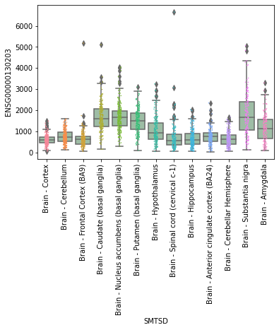

```python
ax = sns.boxplot(x='SMTSD', y=gen, data=teixits, color='#99c2a2')
ax = sns.stripplot(x='SMTSD', y=gen, data=teixits, jitter=True, size=1.5)
plt.setp(ax.get_xticklabels(), rotation=90)
plt.show()
```

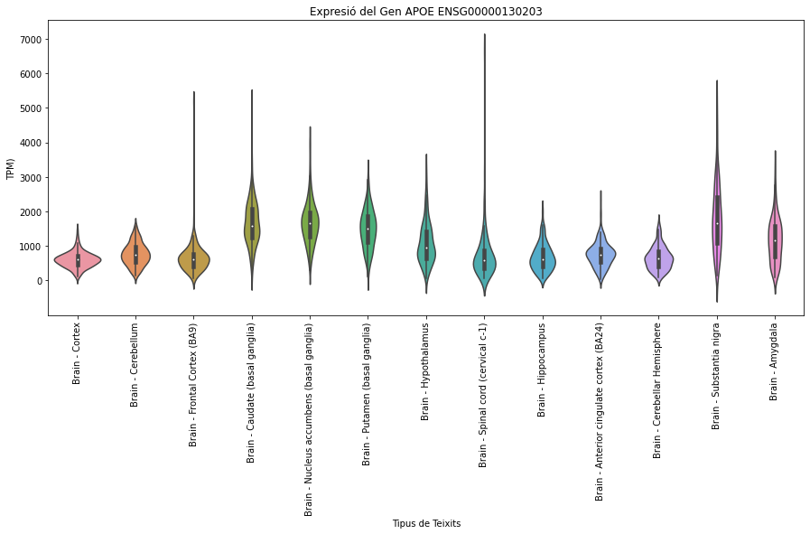

```python
plt.figure(figsize=(15,6))

ax = sns.violinplot(x="SMTSD", y=gen, data=teixits)

ax.set_title("Expresió del Gen APOE " + gen)
ax.set_ylabel("TPM)")
ax.set_xlabel("Tipus de Teixits")

plt.xticks(rotation=90)

plt.show()
```